# canada immigration

```python
import pandas as pd
import numpy as np
import matplotlib.pyplot as plt
import seaborn as sns
```

## Reading the excel file -and reading the relatable file

```python
canada=pd.read_excel('Canada.xlsx',sheet_name="Canada by Citizenship",skiprows=range(20),skipfooter=2)
canada.head()
```

|  | Type | Coverage | OdName | AREA | AreaName | REG | RegName | DEV | DevName | 1980 | ... | 2004 | 2005 | 2006 | 2007 | 2008 | 2009 | 2010 | 2011 | 2012 | 2013 |
| --- | --- | --- | --- | --- | --- | --- | --- | --- | --- | --- | --- | --- | --- | --- | --- | --- | --- | --- | --- | --- | --- |
| 0 | Immigrants | Foreigners | Afghanistan | 935 | Asia | 5501 | Southern Asia | 902 | Developing regions | 16 | ... | 2978 | 3436 | 3009 | 2652 | 2111 | 1746 | 1758 | 2203 | 2635 | 2004 |
| 1 | Immigrants | Foreigners | Albania | 908 | Europe | 925 | Southern Europe | 901 | Developed regions | 1 | ... | 1450 | 1223 | 856 | 702 | 560 | 716 | 561 | 539 | 620 | 603 |
| 2 | Immigrants | Foreigners | Algeria | 903 | Africa | 912 | Northern Africa | 902 | Developing regions | 80 | ... | 3616 | 3626 | 4807 | 3623 | 4005 | 5393 | 4752 | 4325 | 3774 | 4331 |
| 3 | Immigrants | Foreigners | American Samoa | 909 | Oceania | 957 | Polynesia | 902 | Developing regions | 0 | ... | 0 | 0 | 1 | 0 | 0 | 0 | 0 | 0 | 0 | 0 |
| 4 | Immigrants | Foreigners | Andorra | 908 | Europe | 925 | Southern Europe | 901 | Developed regions | 0 | ... | 0 | 0 | 1 | 1 | 0 | 0 | 0 | 0 | 1 | 1 |

5 rows × 43 columns

```python
canada['AreaName'].value_counts()# how many immigrants from different continents
```

```
Africa                             54
Asia                               49
Europe                             43
Latin America and the Caribbean    33
Oceania                            14
Northern America                    2
Name: AreaName, dtype: int64
```

```python
canada['OdName'].value_counts().head()
```

```
Italy                   1
Cyprus                  1
Estonia                 1
Syrian Arab Republic    1
Rwanda                  1
Name: OdName, dtype: int64
```

# #1. Draw a line plot for Immigration from Haiti from 2005-2013

```python
# reading the data
```

```python
can=pd.read_excel('Canada.xlsx',sheet_name="Canada by Citizenship",skiprows=range(20),skipfooter=2)
can.head()
```

|  | Type | Coverage | OdName | AREA | AreaName | REG | RegName | DEV | DevName | 1980 | ... | 2004 | 2005 | 2006 | 2007 | 2008 | 2009 | 2010 | 2011 | 2012 | 2013 |
| --- | --- | --- | --- | --- | --- | --- | --- | --- | --- | --- | --- | --- | --- | --- | --- | --- | --- | --- | --- | --- | --- |
| 0 | Immigrants | Foreigners | Afghanistan | 935 | Asia | 5501 | Southern Asia | 902 | Developing regions | 16 | ... | 2978 | 3436 | 3009 | 2652 | 2111 | 1746 | 1758 | 2203 | 2635 | 2004 |
| 1 | Immigrants | Foreigners | Albania | 908 | Europe | 925 | Southern Europe | 901 | Developed regions | 1 | ... | 1450 | 1223 | 856 | 702 | 560 | 716 | 561 | 539 | 620 | 603 |
| 2 | Immigrants | Foreigners | Algeria | 903 | Africa | 912 | Northern Africa | 902 | Developing regions | 80 | ... | 3616 | 3626 | 4807 | 3623 | 4005 | 5393 | 4752 | 4325 | 3774 | 4331 |
| 3 | Immigrants | Foreigners | American Samoa | 909 | Oceania | 957 | Polynesia | 902 | Developing regions | 0 | ... | 0 | 0 | 1 | 0 | 0 | 0 | 0 | 0 | 0 | 0 |
| 4 | Immigrants | Foreigners | Andorra | 908 | Europe | 925 | Southern Europe | 901 | Developed regions | 0 | ... | 0 | 0 | 1 | 1 | 0 | 0 | 0 | 0 | 1 | 1 |

5 rows × 43 columns

```python
can.rename(columns={"OdName":"Country","AreaName":"Continent","RegName":"Region"},inplace=True)
```

```python
can.set_index('Country')
#can.drop(columns=['AREA','REG','DEV'],inplace=True)
```

| Country | Type | Coverage | AREA | Continent | REG | Region | DEV | DevName | 1980 | 1981 | ... | 2004 | 2005 | 2006 | 2007 | 2008 | 2009 | 2010 | 2011 | 2012 | 2013 |
| --- | --- | --- | --- | --- | --- | --- | --- | --- | --- | --- | --- | --- | --- | --- | --- | --- | --- | --- | --- | --- | --- |
| Afghanistan | Immigrants | Foreigners | 935 | Asia | 5501 | Southern Asia | 902 | Developing regions | 16 | 39 | ... | 2978 | 3436 | 3009 | 2652 | 2111 | 1746 | 1758 | 2203 | 2635 | 2004 |
| Albania | Immigrants | Foreigners | 908 | Europe | 925 | Southern Europe | 901 | Developed regions | 1 | 0 | ... | 1450 | 1223 | 856 | 702 | 560 | 716 | 561 | 539 | 620 | 603 |
| Algeria | Immigrants | Foreigners | 903 | Africa | 912 | Northern Africa | 902 | Developing regions | 80 | 67 | ... | 3616 | 3626 | 4807 | 3623 | 4005 | 5393 | 4752 | 4325 | 3774 | 4331 |
| American Samoa | Immigrants | Foreigners | 909 | Oceania | 957 | Polynesia | 902 | Developing regions | 0 | 1 | ... | 0 | 0 | 1 | 0 | 0 | 0 | 0 | 0 | 0 | 0 |
| Andorra | Immigrants | Foreigners | 908 | Europe | 925 | Southern Europe | 901 | Developed regions | 0 | 0 | ... | 0 | 0 | 1 | 1 | 0 | 0 | 0 | 0 | 1 | 1 |
| Angola | Immigrants | Foreigners | 903 | Africa | 911 | Middle Africa | 902 | Developing regions | 1 | 3 | ... | 268 | 295 | 184 | 106 | 76 | 62 | 61 | 39 | 70 | 45 |
| Antigua and Barbuda | Immigrants | Foreigners | 904 | Latin America and the Caribbean | 915 | Caribbean | 902 | Developing regions | 0 | 0 | ... | 14 | 24 | 32 | 15 | 32 | 38 | 27 | 37 | 51 | 25 |
| Argentina | Immigrants | Foreigners | 904 | Latin America and the Caribbean | 931 | South America | 902 | Developing regions | 368 | 426 | ... | 1591 | 1153 | 847 | 620 | 540 | 467 | 459 | 278 | 263 | 282 |
| Armenia | Immigrants | Foreigners | 935 | Asia | 922 | Western Asia | 902 | Developing regions | 0 | 0 | ... | 147 | 224 | 218 | 198 | 205 | 267 | 252 | 236 | 258 | 207 |
| Australia | Immigrants | Foreigners | 909 | Oceania | 927 | Australia and New Zealand | 901 | Developed regions | 702 | 639 | ... | 930 | 909 | 875 | 1033 | 1018 | 1018 | 933 | 851 | 982 | 1121 |
| Austria | Immigrants | Foreigners | 908 | Europe | 926 | Western Europe | 901 | Developed regions | 234 | 238 | ... | 118 | 122 | 102 | 98 | 91 | 109 | 124 | 84 | 102 | 90 |
| Azerbaijan | Immigrants | Foreigners | 935 | Asia | 922 | Western Asia | 902 | Developing regions | 0 | 0 | ... | 230 | 359 | 236 | 203 | 125 | 165 | 209 | 138 | 161 | 57 |
| Bahamas | Immigrants | Foreigners | 904 | Latin America and the Caribbean | 915 | Caribbean | 902 | Developing regions | 26 | 23 | ... | 13 | 14 | 18 | 23 | 30 | 27 | 25 | 40 | 60 | 55 |
| Bahrain | Immigrants | Foreigners | 935 | Asia | 922 | Western Asia | 902 | Developing regions | 0 | 2 | ... | 12 | 12 | 12 | 22 | 9 | 35 | 28 | 21 | 39 | 32 |
| Bangladesh | Immigrants | Foreigners | 935 | Asia | 5501 | Southern Asia | 902 | Developing regions | 83 | 84 | ... | 2660 | 4171 | 4014 | 2897 | 2939 | 2104 | 4721 | 2694 | 2640 | 3789 |
| Barbados | Immigrants | Foreigners | 904 | Latin America and the Caribbean | 915 | Caribbean | 902 | Developing regions | 372 | 376 | ... | 90 | 111 | 97 | 130 | 134 | 125 | 121 | 97 | 132 | 97 |
| Belarus | Immigrants | Foreigners | 908 | Europe | 923 | Eastern Europe | 901 | Developed regions | 0 | 0 | ... | 543 | 558 | 439 | 568 | 524 | 454 | 438 | 357 | 277 | 247 |
| Belgium | Immigrants | Foreigners | 908 | Europe | 926 | Western Europe | 901 | Developed regions | 511 | 540 | ... | 411 | 400 | 302 | 363 | 335 | 358 | 363 | 332 | 402 | 379 |
| Belize | Immigrants | Foreigners | 904 | Latin America and the Caribbean | 916 | Central America | 902 | Developing regions | 16 | 27 | ... | 25 | 37 | 24 | 28 | 48 | 38 | 39 | 36 | 34 | 53 |
| Benin | Immigrants | Foreigners | 903 | Africa | 914 | Western Africa | 902 | Developing regions | 2 | 5 | ... | 112 | 95 | 116 | 183 | 205 | 238 | 290 | 284 | 391 | 397 |
| Bhutan | Immigrants | Foreigners | 935 | Asia | 5501 | Southern Asia | 902 | Developing regions | 0 | 0 | ... | 1 | 5 | 10 | 7 | 36 | 865 | 1464 | 1879 | 1075 | 487 |
| Bolivia (Plurinational State of) | Immigrants | Foreigners | 904 | Latin America and the Caribbean | 931 | South America | 902 | Developing regions | 44 | 52 | ... | 85 | 134 | 139 | 107 | 143 | 214 | 180 | 86 | 83 | 107 |
| Bosnia and Herzegovina | Immigrants | Foreigners | 908 | Europe | 925 | Southern Europe | 901 | Developed regions | 0 | 0 | ... | 188 | 211 | 217 | 209 | 182 | 156 | 168 | 140 | 121 | 119 |
| Botswana | Immigrants | Foreigners | 903 | Africa | 913 | Southern Africa | 902 | Developing regions | 10 | 1 | ... | 9 | 7 | 11 | 8 | 28 | 15 | 42 | 53 | 64 | 76 |
| Brazil | Immigrants | Foreigners | 904 | Latin America and the Caribbean | 931 | South America | 902 | Developing regions | 211 | 220 | ... | 917 | 969 | 1181 | 1746 | 2138 | 2509 | 2598 | 1508 | 1642 | 1714 |
| Brunei Darussalam | Immigrants | Foreigners | 935 | Asia | 920 | South-Eastern Asia | 902 | Developing regions | 79 | 6 | ... | 3 | 4 | 5 | 11 | 10 | 5 | 12 | 6 | 3 | 6 |
| Bulgaria | Immigrants | Foreigners | 908 | Europe | 923 | Eastern Europe | 901 | Developed regions | 24 | 20 | ... | 2022 | 1738 | 1419 | 1172 | 994 | 784 | 556 | 365 | 451 | 512 |
| Burkina Faso | Immigrants | Foreigners | 903 | Africa | 914 | Western Africa | 902 | Developing regions | 2 | 1 | ... | 97 | 91 | 147 | 136 | 139 | 162 | 186 | 144 | 269 | 322 |
| Burundi | Immigrants | Foreigners | 903 | Africa | 910 | Eastern Africa | 902 | Developing regions | 0 | 0 | ... | 559 | 626 | 468 | 614 | 448 | 566 | 529 | 604 | 684 | 480 |
| Cabo Verde | Immigrants | Foreigners | 903 | Africa | 914 | Western Africa | 902 | Developing regions | 1 | 1 | ... | 3 | 5 | 7 | 2 | 5 | 1 | 3 | 3 | 6 | 2 |
| ... | ... | ... | ... | ... | ... | ... | ... | ... | ... | ... | ... | ... | ... | ... | ... | ... | ... | ... | ... | ... | ... |
| Suriname | Immigrants | Foreigners | 904 | Latin America and the Caribbean | 931 | South America | 902 | Developing regions | 15 | 10 | ... | 17 | 15 | 16 | 20 | 9 | 12 | 13 | 11 | 16 | 4 |
| Swaziland | Immigrants | Foreigners | 903 | Africa | 913 | Southern Africa | 902 | Developing regions | 4 | 1 | ... | 8 | 7 | 7 | 5 | 6 | 10 | 3 | 13 | 17 | 39 |
| Sweden | Immigrants | Foreigners | 908 | Europe | 924 | Northern Europe | 901 | Developed regions | 281 | 308 | ... | 129 | 205 | 139 | 193 | 165 | 167 | 159 | 134 | 140 | 140 |
| Switzerland | Immigrants | Foreigners | 908 | Europe | 926 | Western Europe | 901 | Developed regions | 806 | 811 | ... | 337 | 270 | 258 | 308 | 357 | 328 | 285 | 266 | 243 | 201 |
| Syrian Arab Republic | Immigrants | Foreigners | 935 | Asia | 922 | Western Asia | 902 | Developing regions | 315 | 419 | ... | 1116 | 1458 | 1145 | 1056 | 919 | 917 | 1039 | 1005 | 650 | 1009 |
| Tajikistan | Immigrants | Foreigners | 935 | Asia | 5500 | Central Asia | 902 | Developing regions | 0 | 0 | ... | 14 | 85 | 46 | 44 | 15 | 50 | 52 | 47 | 34 | 39 |
| Thailand | Immigrants | Foreigners | 935 | Asia | 920 | South-Eastern Asia | 902 | Developing regions | 56 | 53 | ... | 392 | 575 | 500 | 487 | 519 | 512 | 499 | 396 | 296 | 400 |
| The former Yugoslav Republic of Macedonia | Immigrants | Foreigners | 908 | Europe | 925 | Southern Europe | 901 | Developed regions | 0 | 0 | ... | 443 | 285 | 256 | 211 | 191 | 198 | 188 | 130 | 126 | 112 |
| Togo | Immigrants | Foreigners | 903 | Africa | 914 | Western Africa | 902 | Developing regions | 5 | 5 | ... | 163 | 157 | 149 | 235 | 351 | 400 | 354 | 261 | 299 | 316 |
| Tonga | Immigrants | Foreigners | 909 | Oceania | 957 | Polynesia | 902 | Developing regions | 2 | 4 | ... | 5 | 2 | 0 | 1 | 0 | 5 | 5 | 2 | 3 | 5 |
| Trinidad and Tobago | Immigrants | Foreigners | 904 | Latin America and the Caribbean | 915 | Caribbean | 902 | Developing regions | 958 | 947 | ... | 730 | 857 | 794 | 975 | 1002 | 1134 | 915 | 588 | 586 | 427 |
| Tunisia | Immigrants | Foreigners | 903 | Africa | 912 | Northern Africa | 902 | Developing regions | 58 | 51 | ... | 764 | 756 | 1065 | 869 | 950 | 1195 | 1299 | 1442 | 1503 | 1627 |
| Turkey | Immigrants | Foreigners | 935 | Asia | 922 | Western Asia | 902 | Developing regions | 481 | 874 | ... | 1736 | 2065 | 1638 | 1463 | 1122 | 1238 | 1492 | 1257 | 1068 | 729 |
| Turkmenistan | Immigrants | Foreigners | 935 | Asia | 5500 | Central Asia | 902 | Developing regions | 0 | 0 | ... | 16 | 40 | 26 | 37 | 13 | 20 | 30 | 20 | 20 | 14 |
| Tuvalu | Immigrants | Foreigners | 909 | Oceania | 957 | Polynesia | 902 | Developing regions | 0 | 1 | ... | 2 | 0 | 0 | 1 | 0 | 0 | 0 | 1 | 0 | 0 |
| Uganda | Immigrants | Foreigners | 903 | Africa | 910 | Eastern Africa | 902 | Developing regions | 13 | 16 | ... | 160 | 239 | 201 | 170 | 204 | 185 | 216 | 213 | 222 | 206 |
| Ukraine | Immigrants | Foreigners | 908 | Europe | 923 | Eastern Europe | 901 | Developed regions | 0 | 0 | ... | 2431 | 2270 | 1973 | 2218 | 1937 | 2367 | 3159 | 2515 | 2265 | 2487 |
| United Arab Emirates | Immigrants | Foreigners | 935 | Asia | 922 | Western Asia | 902 | Developing regions | 0 | 2 | ... | 41 | 31 | 42 | 37 | 33 | 37 | 86 | 60 | 54 | 46 |
| United Kingdom of Great Britain and Northern Ireland | Immigrants | Foreigners | 908 | Europe | 924 | Northern Europe | 901 | Developed regions | 22045 | 24796 | ... | 7533 | 7258 | 7140 | 8216 | 8979 | 8876 | 8724 | 6204 | 6195 | 5827 |
| United Republic of Tanzania | Immigrants | Foreigners | 903 | Africa | 910 | Eastern Africa | 902 | Developing regions | 635 | 832 | ... | 310 | 274 | 291 | 195 | 230 | 136 | 200 | 215 | 224 | 182 |
| United States of America | Immigrants | Foreigners | 905 | Northern America | 905 | Northern America | 901 | Developed regions | 9378 | 10030 | ... | 6990 | 8394 | 9613 | 9463 | 10190 | 8995 | 8142 | 7676 | 7891 | 8501 |
| Uruguay | Immigrants | Foreigners | 904 | Latin America and the Caribbean | 931 | South America | 902 | Developing regions | 128 | 132 | ... | 130 | 217 | 175 | 147 | 160 | 99 | 93 | 81 | 47 | 58 |
| Uzbekistan | Immigrants | Foreigners | 935 | Asia | 5500 | Central Asia | 902 | Developing regions | 0 | 0 | ... | 175 | 330 | 262 | 284 | 215 | 288 | 289 | 162 | 235 | 167 |
| Vanuatu | Immigrants | Foreigners | 909 | Oceania | 928 | Melanesia | 902 | Developing regions | 0 | 0 | ... | 1 | 1 | 1 | 0 | 0 | 1 | 0 | 0 | 0 | 0 |
| Venezuela (Bolivarian Republic of) | Immigrants | Foreigners | 904 | Latin America and the Caribbean | 931 | South America | 902 | Developing regions | 103 | 117 | ... | 1224 | 1211 | 1192 | 1335 | 1239 | 1353 | 998 | 1452 | 1373 | 1022 |
| Viet Nam | Immigrants | Foreigners | 935 | Asia | 920 | South-Eastern Asia | 902 | Developing regions | 1191 | 1829 | ... | 1816 | 1852 | 3153 | 2574 | 1784 | 2171 | 1942 | 1723 | 1731 | 2112 |
| Western Sahara | Immigrants | Foreigners | 903 | Africa | 912 | Northern Africa | 902 | Developing regions | 0 | 0 | ... | 0 | 0 | 1 | 0 | 0 | 0 | 0 | 0 | 0 | 0 |
| Yemen | Immigrants | Foreigners | 935 | Asia | 922 | Western Asia | 902 | Developing regions | 1 | 2 | ... | 124 | 161 | 140 | 122 | 133 | 128 | 211 | 160 | 174 | 217 |
| Zambia | Immigrants | Foreigners | 903 | Africa | 910 | Eastern Africa | 902 | Developing regions | 11 | 17 | ... | 56 | 91 | 77 | 71 | 64 | 60 | 102 | 69 | 46 | 59 |
| Zimbabwe | Immigrants | Foreigners | 903 | Africa | 910 | Eastern Africa | 902 | Developing regions | 72 | 114 | ... | 1450 | 615 | 454 | 663 | 611 | 508 | 494 | 434 | 437 | 407 |

195 rows × 42 columns

```python
can['Total']=can.sum(axis=1)
can
```

|  | Type | Coverage | Country | AREA | Continent | REG | Region | DEV | DevName | 1980 | ... | 2005 | 2006 | 2007 | 2008 | 2009 | 2010 | 2011 | 2012 | 2013 | Total |
| --- | --- | --- | --- | --- | --- | --- | --- | --- | --- | --- | --- | --- | --- | --- | --- | --- | --- | --- | --- | --- | --- |
| 0 | Immigrants | Foreigners | Afghanistan | 935 | Asia | 5501 | Southern Asia | 902 | Developing regions | 16 | ... | 3436 | 3009 | 2652 | 2111 | 1746 | 1758 | 2203 | 2635 | 2004 | 65977 |
| 1 | Immigrants | Foreigners | Albania | 908 | Europe | 925 | Southern Europe | 901 | Developed regions | 1 | ... | 1223 | 856 | 702 | 560 | 716 | 561 | 539 | 620 | 603 | 18433 |
| 2 | Immigrants | Foreigners | Algeria | 903 | Africa | 912 | Northern Africa | 902 | Developing regions | 80 | ... | 3626 | 4807 | 3623 | 4005 | 5393 | 4752 | 4325 | 3774 | 4331 | 72156 |
| 3 | Immigrants | Foreigners | American Samoa | 909 | Oceania | 957 | Polynesia | 902 | Developing regions | 0 | ... | 0 | 1 | 0 | 0 | 0 | 0 | 0 | 0 | 0 | 2774 |
| 4 | Immigrants | Foreigners | Andorra | 908 | Europe | 925 | Southern Europe | 901 | Developed regions | 0 | ... | 0 | 1 | 1 | 0 | 0 | 0 | 0 | 1 | 1 | 2749 |
| 5 | Immigrants | Foreigners | Angola | 903 | Africa | 911 | Middle Africa | 902 | Developing regions | 1 | ... | 295 | 184 | 106 | 76 | 62 | 61 | 39 | 70 | 45 | 4829 |
| 6 | Immigrants | Foreigners | Antigua and Barbuda | 904 | Latin America and the Caribbean | 915 | Caribbean | 902 | Developing regions | 0 | ... | 24 | 32 | 15 | 32 | 38 | 27 | 37 | 51 | 25 | 3702 |
| 7 | Immigrants | Foreigners | Argentina | 904 | Latin America and the Caribbean | 931 | South America | 902 | Developing regions | 368 | ... | 1153 | 847 | 620 | 540 | 467 | 459 | 278 | 263 | 282 | 22333 |
| 8 | Immigrants | Foreigners | Armenia | 935 | Asia | 922 | Western Asia | 902 | Developing regions | 0 | ... | 224 | 218 | 198 | 205 | 267 | 252 | 236 | 258 | 207 | 6069 |
| 9 | Immigrants | Foreigners | Australia | 909 | Oceania | 927 | Australia and New Zealand | 901 | Developed regions | 702 | ... | 909 | 875 | 1033 | 1018 | 1018 | 933 | 851 | 982 | 1121 | 26566 |
| 10 | Immigrants | Foreigners | Austria | 908 | Europe | 926 | Western Europe | 901 | Developed regions | 234 | ... | 122 | 102 | 98 | 91 | 109 | 124 | 84 | 102 | 90 | 7720 |
| 11 | Immigrants | Foreigners | Azerbaijan | 935 | Asia | 922 | Western Asia | 902 | Developing regions | 0 | ... | 359 | 236 | 203 | 125 | 165 | 209 | 138 | 161 | 57 | 5408 |
| 12 | Immigrants | Foreigners | Bahamas | 904 | Latin America and the Caribbean | 915 | Caribbean | 902 | Developing regions | 26 | ... | 14 | 18 | 23 | 30 | 27 | 25 | 40 | 60 | 55 | 3529 |
| 13 | Immigrants | Foreigners | Bahrain | 935 | Asia | 922 | Western Asia | 902 | Developing regions | 0 | ... | 12 | 12 | 22 | 9 | 35 | 28 | 21 | 39 | 32 | 3234 |
| 14 | Immigrants | Foreigners | Bangladesh | 935 | Asia | 5501 | Southern Asia | 902 | Developing regions | 83 | ... | 4171 | 4014 | 2897 | 2939 | 2104 | 4721 | 2694 | 2640 | 3789 | 72906 |
| 15 | Immigrants | Foreigners | Barbados | 904 | Latin America and the Caribbean | 915 | Caribbean | 902 | Developing regions | 372 | ... | 111 | 97 | 130 | 134 | 125 | 121 | 97 | 132 | 97 | 9644 |
| 16 | Immigrants | Foreigners | Belarus | 908 | Europe | 923 | Eastern Europe | 901 | Developed regions | 0 | ... | 558 | 439 | 568 | 524 | 454 | 438 | 357 | 277 | 247 | 10707 |
| 17 | Immigrants | Foreigners | Belgium | 908 | Europe | 926 | Western Europe | 901 | Developed regions | 511 | ... | 400 | 302 | 363 | 335 | 358 | 363 | 332 | 402 | 379 | 13497 |
| 18 | Immigrants | Foreigners | Belize | 904 | Latin America and the Caribbean | 916 | Central America | 902 | Developing regions | 16 | ... | 37 | 24 | 28 | 48 | 38 | 39 | 36 | 34 | 53 | 3805 |
| 19 | Immigrants | Foreigners | Benin | 903 | Africa | 914 | Western Africa | 902 | Developing regions | 2 | ... | 95 | 116 | 183 | 205 | 238 | 290 | 284 | 391 | 397 | 5571 |
| 20 | Immigrants | Foreigners | Bhutan | 935 | Asia | 5501 | Southern Asia | 902 | Developing regions | 0 | ... | 5 | 10 | 7 | 36 | 865 | 1464 | 1879 | 1075 | 487 | 13214 |
| 21 | Immigrants | Foreigners | Bolivia (Plurinational State of) | 904 | Latin America and the Caribbean | 931 | South America | 902 | Developing regions | 44 | ... | 134 | 139 | 107 | 143 | 214 | 180 | 86 | 83 | 107 | 5942 |
| 22 | Immigrants | Foreigners | Bosnia and Herzegovina | 908 | Europe | 925 | Southern Europe | 901 | Developed regions | 0 | ... | 211 | 217 | 209 | 182 | 156 | 168 | 140 | 121 | 119 | 24589 |
| 23 | Immigrants | Foreigners | Botswana | 903 | Africa | 913 | Southern Africa | 902 | Developing regions | 10 | ... | 7 | 11 | 8 | 28 | 15 | 42 | 53 | 64 | 76 | 3114 |
| 24 | Immigrants | Foreigners | Brazil | 904 | Latin America and the Caribbean | 931 | South America | 902 | Developing regions | 211 | ... | 969 | 1181 | 1746 | 2138 | 2509 | 2598 | 1508 | 1642 | 1714 | 32396 |
| 25 | Immigrants | Foreigners | Brunei Darussalam | 935 | Asia | 920 | South-Eastern Asia | 902 | Developing regions | 79 | ... | 4 | 5 | 11 | 10 | 5 | 12 | 6 | 3 | 6 | 3357 |
| 26 | Immigrants | Foreigners | Bulgaria | 908 | Europe | 923 | Eastern Europe | 901 | Developed regions | 24 | ... | 1738 | 1419 | 1172 | 994 | 784 | 556 | 365 | 451 | 512 | 26042 |
| 27 | Immigrants | Foreigners | Burkina Faso | 903 | Africa | 914 | Western Africa | 902 | Developing regions | 2 | ... | 91 | 147 | 136 | 139 | 162 | 186 | 144 | 269 | 322 | 4762 |
| 28 | Immigrants | Foreigners | Burundi | 903 | Africa | 910 | Eastern Africa | 902 | Developing regions | 0 | ... | 626 | 468 | 614 | 448 | 566 | 529 | 604 | 684 | 480 | 10825 |
| 29 | Immigrants | Foreigners | Cabo Verde | 903 | Africa | 914 | Western Africa | 902 | Developing regions | 1 | ... | 5 | 7 | 2 | 5 | 1 | 3 | 3 | 6 | 2 | 2920 |
| ... | ... | ... | ... | ... | ... | ... | ... | ... | ... | ... | ... | ... | ... | ... | ... | ... | ... | ... | ... | ... | ... |
| 165 | Immigrants | Foreigners | Suriname | 904 | Latin America and the Caribbean | 931 | South America | 902 | Developing regions | 15 | ... | 15 | 16 | 20 | 9 | 12 | 13 | 11 | 16 | 4 | 3476 |
| 166 | Immigrants | Foreigners | Swaziland | 903 | Africa | 913 | Southern Africa | 902 | Developing regions | 4 | ... | 7 | 7 | 5 | 6 | 10 | 3 | 13 | 17 | 39 | 2906 |
| 167 | Immigrants | Foreigners | Sweden | 908 | Europe | 924 | Northern Europe | 901 | Developed regions | 281 | ... | 205 | 139 | 193 | 165 | 167 | 159 | 134 | 140 | 140 | 8599 |
| 168 | Immigrants | Foreigners | Switzerland | 908 | Europe | 926 | Western Europe | 901 | Developed regions | 806 | ... | 270 | 258 | 308 | 357 | 328 | 285 | 266 | 243 | 201 | 18413 |
| 169 | Immigrants | Foreigners | Syrian Arab Republic | 935 | Asia | 922 | Western Asia | 902 | Developing regions | 315 | ... | 1458 | 1145 | 1056 | 919 | 917 | 1039 | 1005 | 650 | 1009 | 34244 |
| 170 | Immigrants | Foreigners | Tajikistan | 935 | Asia | 5500 | Central Asia | 902 | Developing regions | 0 | ... | 85 | 46 | 44 | 15 | 50 | 52 | 47 | 34 | 39 | 7840 |
| 171 | Immigrants | Foreigners | Thailand | 935 | Asia | 920 | South-Eastern Asia | 902 | Developing regions | 56 | ... | 575 | 500 | 487 | 519 | 512 | 499 | 396 | 296 | 400 | 11931 |
| 172 | Immigrants | Foreigners | The former Yugoslav Republic of Macedonia | 908 | Europe | 925 | Southern Europe | 901 | Developed regions | 0 | ... | 285 | 256 | 211 | 191 | 198 | 188 | 130 | 126 | 112 | 7371 |
| 173 | Immigrants | Foreigners | Togo | 903 | Africa | 914 | Western Africa | 902 | Developing regions | 5 | ... | 157 | 149 | 235 | 351 | 400 | 354 | 261 | 299 | 316 | 6264 |
| 174 | Immigrants | Foreigners | Tonga | 909 | Oceania | 957 | Polynesia | 902 | Developing regions | 2 | ... | 2 | 0 | 1 | 0 | 5 | 5 | 2 | 3 | 5 | 2910 |
| 175 | Immigrants | Foreigners | Trinidad and Tobago | 904 | Latin America and the Caribbean | 915 | Caribbean | 902 | Developing regions | 958 | ... | 857 | 794 | 975 | 1002 | 1134 | 915 | 588 | 586 | 427 | 52737 |
| 176 | Immigrants | Foreigners | Tunisia | 903 | Africa | 912 | Northern Africa | 902 | Developing regions | 58 | ... | 756 | 1065 | 869 | 950 | 1195 | 1299 | 1442 | 1503 | 1627 | 20300 |
| 177 | Immigrants | Foreigners | Turkey | 935 | Asia | 922 | Western Asia | 902 | Developing regions | 481 | ... | 2065 | 1638 | 1463 | 1122 | 1238 | 1492 | 1257 | 1068 | 729 | 34540 |
| 178 | Immigrants | Foreigners | Turkmenistan | 935 | Asia | 5500 | Central Asia | 902 | Developing regions | 0 | ... | 40 | 26 | 37 | 13 | 20 | 30 | 20 | 20 | 14 | 7647 |
| 179 | Immigrants | Foreigners | Tuvalu | 909 | Oceania | 957 | Polynesia | 902 | Developing regions | 0 | ... | 0 | 0 | 1 | 0 | 0 | 0 | 1 | 0 | 0 | 2776 |
| 180 | Immigrants | Foreigners | Uganda | 903 | Africa | 910 | Eastern Africa | 902 | Developing regions | 13 | ... | 239 | 201 | 170 | 204 | 185 | 216 | 213 | 222 | 206 | 6165 |
| 181 | Immigrants | Foreigners | Ukraine | 908 | Europe | 923 | Eastern Europe | 901 | Developed regions | 0 | ... | 2270 | 1973 | 2218 | 1937 | 2367 | 3159 | 2515 | 2265 | 2487 | 54142 |
| 182 | Immigrants | Foreigners | United Arab Emirates | 935 | Asia | 922 | Western Asia | 902 | Developing regions | 0 | ... | 31 | 42 | 37 | 33 | 37 | 86 | 60 | 54 | 46 | 3595 |
| 183 | Immigrants | Foreigners | United Kingdom of Great Britain and Northern I... | 908 | Europe | 924 | Northern Europe | 901 | Developed regions | 22045 | ... | 7258 | 7140 | 8216 | 8979 | 8876 | 8724 | 6204 | 6195 | 5827 | 554233 |
| 184 | Immigrants | Foreigners | United Republic of Tanzania | 903 | Africa | 910 | Eastern Africa | 902 | Developing regions | 635 | ... | 274 | 291 | 195 | 230 | 136 | 200 | 215 | 224 | 182 | 15211 |
| 185 | Immigrants | Foreigners | United States of America | 905 | Northern America | 905 | Northern America | 901 | Developed regions | 9378 | ... | 8394 | 9613 | 9463 | 10190 | 8995 | 8142 | 7676 | 7891 | 8501 | 243833 |
| 186 | Immigrants | Foreigners | Uruguay | 904 | Latin America and the Caribbean | 931 | South America | 902 | Developing regions | 128 | ... | 217 | 175 | 147 | 160 | 99 | 93 | 81 | 47 | 58 | 7452 |
| 187 | Immigrants | Foreigners | Uzbekistan | 935 | Asia | 5500 | Central Asia | 902 | Developing regions | 0 | ... | 330 | 262 | 284 | 215 | 288 | 289 | 162 | 235 | 167 | 10705 |
| 188 | Immigrants | Foreigners | Vanuatu | 909 | Oceania | 928 | Melanesia | 902 | Developing regions | 0 | ... | 1 | 1 | 0 | 0 | 1 | 0 | 0 | 0 | 0 | 2750 |
| 189 | Immigrants | Foreigners | Venezuela (Bolivarian Republic of) | 904 | Latin America and the Caribbean | 931 | South America | 902 | Developing regions | 103 | ... | 1211 | 1192 | 1335 | 1239 | 1353 | 998 | 1452 | 1373 | 1022 | 24004 |
| 190 | Immigrants | Foreigners | Viet Nam | 935 | Asia | 920 | South-Eastern Asia | 902 | Developing regions | 1191 | ... | 1852 | 3153 | 2574 | 1784 | 2171 | 1942 | 1723 | 1731 | 2112 | 99903 |
| 191 | Immigrants | Foreigners | Western Sahara | 903 | Africa | 912 | Northern Africa | 902 | Developing regions | 0 | ... | 0 | 1 | 0 | 0 | 0 | 0 | 0 | 0 | 0 | 2719 |
| 192 | Immigrants | Foreigners | Yemen | 935 | Asia | 922 | Western Asia | 902 | Developing regions | 1 | ... | 161 | 140 | 122 | 133 | 128 | 211 | 160 | 174 | 217 | 5744 |
| 193 | Immigrants | Foreigners | Zambia | 903 | Africa | 910 | Eastern Africa | 902 | Developing regions | 11 | ... | 91 | 77 | 71 | 64 | 60 | 102 | 69 | 46 | 59 | 4392 |
| 194 | Immigrants | Foreigners | Zimbabwe | 903 | Africa | 910 | Eastern Africa | 902 | Developing regions | 72 | ... | 615 | 454 | 663 | 611 | 508 | 494 | 434 | 437 | 407 | 11313 |

195 rows × 44 columns

```python
# finding null values
can.isnull().sum()
```

```
Type         0
Coverage     0
Country      0
AREA         0
Continent    0
REG          0
Region       0
DEV          0
DevName      0
1980         0
1981         0
1982         0
1983         0
1984         0
1985         0
```

[output cut: 30 more lines]

```python
can1=can[['Country',1980,1981,1982,1983,1984,1985]]
can1
```

|  | Country | 1980 | 1981 | 1982 | 1983 | 1984 | 1985 |
| --- | --- | --- | --- | --- | --- | --- | --- |
| 0 | Afghanistan | 16 | 39 | 39 | 47 | 71 | 340 |
| 1 | Albania | 1 | 0 | 0 | 0 | 0 | 0 |
| 2 | Algeria | 80 | 67 | 71 | 69 | 63 | 44 |
| 3 | American Samoa | 0 | 1 | 0 | 0 | 0 | 0 |
| 4 | Andorra | 0 | 0 | 0 | 0 | 0 | 0 |
| 5 | Angola | 1 | 3 | 6 | 6 | 4 | 3 |
| 6 | Antigua and Barbuda | 0 | 0 | 0 | 0 | 42 | 52 |
| 7 | Argentina | 368 | 426 | 626 | 241 | 237 | 196 |
| 8 | Armenia | 0 | 0 | 0 | 0 | 0 | 0 |
| 9 | Australia | 702 | 639 | 484 | 317 | 317 | 319 |
| 10 | Austria | 234 | 238 | 201 | 117 | 127 | 165 |
| 11 | Azerbaijan | 0 | 0 | 0 | 0 | 0 | 0 |
| 12 | Bahamas | 26 | 23 | 38 | 12 | 21 | 28 |
| 13 | Bahrain | 0 | 2 | 1 | 1 | 1 | 3 |
| 14 | Bangladesh | 83 | 84 | 86 | 81 | 98 | 92 |
| 15 | Barbados | 372 | 376 | 299 | 244 | 265 | 285 |
| 16 | Belarus | 0 | 0 | 0 | 0 | 0 | 0 |
| 17 | Belgium | 511 | 540 | 519 | 297 | 183 | 181 |
| 18 | Belize | 16 | 27 | 13 | 21 | 37 | 26 |
| 19 | Benin | 2 | 5 | 4 | 3 | 4 | 3 |
| 20 | Bhutan | 0 | 0 | 0 | 0 | 1 | 0 |
| 21 | Bolivia (Plurinational State of) | 44 | 52 | 42 | 49 | 38 | 44 |
| 22 | Bosnia and Herzegovina | 0 | 0 | 0 | 0 | 0 | 0 |
| 23 | Botswana | 10 | 1 | 3 | 3 | 7 | 4 |
| 24 | Brazil | 211 | 220 | 192 | 139 | 145 | 130 |
| 25 | Brunei Darussalam | 79 | 6 | 8 | 2 | 2 | 4 |
| 26 | Bulgaria | 24 | 20 | 12 | 33 | 11 | 24 |
| 27 | Burkina Faso | 2 | 1 | 3 | 2 | 3 | 2 |
| 28 | Burundi | 0 | 0 | 0 | 0 | 1 | 2 |
| 29 | Cabo Verde | 1 | 1 | 2 | 0 | 11 | 1 |
| ... | ... | ... | ... | ... | ... | ... | ... |
| 165 | Suriname | 15 | 10 | 21 | 12 | 5 | 16 |
| 166 | Swaziland | 4 | 1 | 1 | 0 | 10 | 7 |
| 167 | Sweden | 281 | 308 | 222 | 176 | 128 | 158 |
| 168 | Switzerland | 806 | 811 | 634 | 370 | 326 | 314 |
| 169 | Syrian Arab Republic | 315 | 419 | 409 | 269 | 264 | 385 |
| 170 | Tajikistan | 0 | 0 | 0 | 0 | 0 | 0 |
| 171 | Thailand | 56 | 53 | 113 | 65 | 82 | 66 |
| 172 | The former Yugoslav Republic of Macedonia | 0 | 0 | 0 | 0 | 0 | 0 |
| 173 | Togo | 5 | 5 | 2 | 3 | 6 | 5 |
| 174 | Tonga | 2 | 4 | 7 | 1 | 2 | 5 |
| 175 | Trinidad and Tobago | 958 | 947 | 972 | 766 | 606 | 699 |
| 176 | Tunisia | 58 | 51 | 55 | 46 | 51 | 57 |
| 177 | Turkey | 481 | 874 | 706 | 280 | 338 | 202 |
| 178 | Turkmenistan | 0 | 0 | 0 | 0 | 0 | 0 |
| 179 | Tuvalu | 0 | 1 | 0 | 0 | 1 | 0 |
| 180 | Uganda | 13 | 16 | 17 | 38 | 32 | 29 |
| 181 | Ukraine | 0 | 0 | 0 | 0 | 0 | 0 |
| 182 | United Arab Emirates | 0 | 2 | 2 | 1 | 2 | 0 |
| 183 | United Kingdom of Great Britain and Northern I... | 22045 | 24796 | 20620 | 10015 | 10170 | 9564 |
| 184 | United Republic of Tanzania | 635 | 832 | 621 | 474 | 473 | 460 |
| 185 | United States of America | 9378 | 10030 | 9074 | 7100 | 6661 | 6543 |
| 186 | Uruguay | 128 | 132 | 146 | 105 | 90 | 92 |
| 187 | Uzbekistan | 0 | 0 | 0 | 0 | 0 | 0 |
| 188 | Vanuatu | 0 | 0 | 0 | 0 | 0 | 0 |
| 189 | Venezuela (Bolivarian Republic of) | 103 | 117 | 174 | 124 | 142 | 165 |
| 190 | Viet Nam | 1191 | 1829 | 2162 | 3404 | 7583 | 5907 |
| 191 | Western Sahara | 0 | 0 | 0 | 0 | 0 | 0 |
| 192 | Yemen | 1 | 2 | 1 | 6 | 0 | 18 |
| 193 | Zambia | 11 | 17 | 11 | 7 | 16 | 9 |
| 194 | Zimbabwe | 72 | 114 | 102 | 44 | 32 | 29 |

195 rows × 7 columns

```python
# find data of american Samoa Country
print(can.loc[3])
```

```
Type                 Immigrants
Coverage             Foreigners
Country          American Samoa
AREA                        909
Continent               Oceania
REG                         957
Region                Polynesia
DEV                         902
DevName      Developing regions
1980                          0
1981                          1
1982                          0
1983                          0
1984                          0
1985                          0
```

[output cut: 30 more lines]

```python
can.set_index('Country',inplace=True)
```

```python
# find data of Algeria Country
print(can.loc['Algeria'])
```

```
Type                 Immigrants
Coverage             Foreigners
AREA                        903
Continent                Africa
REG                         912
Region          Northern Africa
DEV                         902
DevName      Developing regions
1980                         80
1981                         67
1982                         71
1983                         69
1984                         63
1985                         44
1986                         69
```

[output cut: 29 more lines]

```python
# find data of Japan from 1989-1984
can.loc['Japan',[1980,1981,1982,1983,1984]]
```

```
1980    701
1981    756
1982    598
1983    309
1984    246
Name: Japan, dtype: object
```

```python
# if country is equal to Asia the True else False
can['Continent']=='Asia'
```

```
Country
Afghanistan                                              True
Albania                                                 False
Algeria                                                 False
American Samoa                                          False
Andorra                                                 False
Angola                                                  False
Antigua and Barbuda                                     False
Argentina                                               False
Armenia                                                  True
Australia                                               False
Austria                                                 False
Azerbaijan                                               True
Bahamas                                                 False
Bahrain                                                  True
Bangladesh                                               True
Barbados                                                False
Belarus                                                 False
Belgium                                                 False
Belize                                                  False
Benin                                                   False
Bhutan                                                   True
Bolivia (Plurinational State of)                        False
Bosnia and Herzegovina                                  False
Botswana                                                False
Brazil                                                  False
Brunei Darussalam                                        True
Bulgaria                                                False
Burkina Faso                                            False
Burundi                                                 False
Cabo Verde                                              False
                                                        ...
Suriname                                                False
Swaziland                                               False
Sweden                                                  False
Switzerland                                             False
Syrian Arab Republic                                     True
Tajikistan                                               True
Thailand                                                 True
The former Yugoslav Republic of Macedonia               False
```

[output cut: 8 more lines]

```
Ukraine                                                 False
United Arab Emirates                                     True
United Kingdom of Great Britain and Northern Ireland    False
United Republic of Tanzania                             False
United States of America                                False
Uruguay                                                 False
Uzbekistan                                               True
Vanuatu                                                 False
Venezuela (Bolivarian Republic of)                      False
Viet Nam                                                 True
Western Sahara                                          False
Yemen                                                    True
Zambia                                                  False
Zimbabwe                                                False
Name: Continent, Length: 195, dtype: bool
```

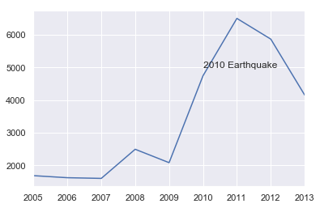

```python
sns.set()
haiti=can.loc['Haiti',[2005,2006,2007,2008,2009,2010,2011,2012,2013]]
plt.text(2010,5000,'2010 Earthquake')
haiti.plot(kind='line')
```

## 3.plot line graph for immigration India,China from 1980 to 2013

```python
years=[1980,1981,1982,1983,1984,1985,1986,1987,1988,1989,1990,1991,1992,1993,1994,1995,1996,1997,1998,1999,2000,2001,2002,2003,2004,2005,2006,2007,2008,2009,2010,2011,2012,2013]
can1=can.loc[['India','China'],years]
can1.head()
```

| Country | 1980 | 1981 | 1982 | 1983 | 1984 | 1985 | 1986 | 1987 | 1988 | 1989 | ... | 2004 | 2005 | 2006 | 2007 | 2008 | 2009 | 2010 | 2011 | 2012 | 2013 |
| --- | --- | --- | --- | --- | --- | --- | --- | --- | --- | --- | --- | --- | --- | --- | --- | --- | --- | --- | --- | --- | --- |
| India | 8880 | 8670 | 8147 | 7338 | 5704 | 4211 | 7150 | 10189 | 11522 | 10343 | ... | 28235 | 36210 | 33848 | 28742 | 28261 | 29456 | 34235 | 27509 | 30933 | 33087 |
| China | 5123 | 6682 | 3308 | 1863 | 1527 | 1816 | 1960 | 2643 | 2758 | 4323 | ... | 36619 | 42584 | 33518 | 27642 | 30037 | 29622 | 30391 | 28502 | 33024 | 34129 |

2 rows × 34 columns

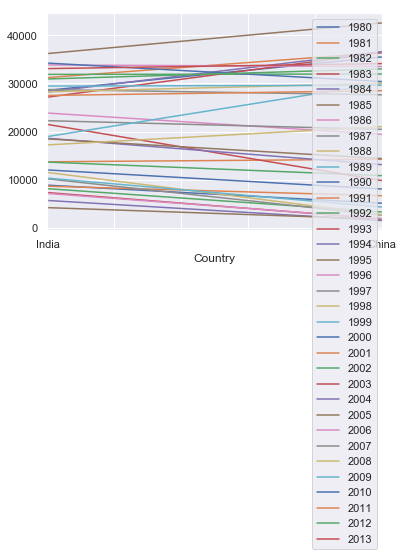

```python
can1.plot(kind='line')
```

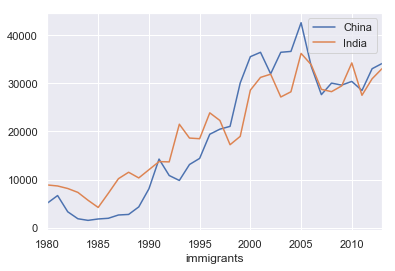

```python
# .....doubt
india=can.loc['India',[1980,1981,1982,1983,1984,1985,1986,1987,1988,1989,1990,1991,1992,1993,1994,1995,1996,1997,1998,1999,2000,2001,2002,2003,2004,2005,2006,2007,2008,2009,2010,2011,2012,2013]]
china=can.loc['China',[1980,1981,1982,1983,1984,1985,1986,1987,1988,1989,1990,1991,1992,1993,1994,1995,1996,1997,1998,1999,2000,2001,2002,2003,2004,2005,2006,2007,2008,2009,2010,2011,2012,2013]]
china.plot(kind='line')
india.plot(kind='line')
plt.xlabel('immigrants')# no of immigrants
plt.legend()
```

```python
can1.transpose().head()
```

| Country | India | China |
| --- | --- | --- |
| 1980 | 8880 | 5123 |
| 1981 | 8670 | 6682 |
| 1982 | 8147 | 3308 |
| 1983 | 7338 | 1863 |
| 1984 | 5704 | 1527 |

```python
#year=list(map(str,range(1980,2014)))## try it out
#year
#year=can.columns=list(map(str,can.columns))
```

# 5.6. Compare the trend of top 5 countries

```python
#can['Total'].nlargest(5)
```

```python
#figure=can['Total'].nlargest(5).plot(kind='line')
```

```python
can.sort_values(by='Total',ascending=False,axis=0,inplace=True)
can2=can.head()
can2
```

| Country | Type | Coverage | AREA | Continent | REG | Region | DEV | DevName | 1980 | 1981 | ... | 2005 | 2006 | 2007 | 2008 | 2009 | 2010 | 2011 | 2012 | 2013 | Total |
| --- | --- | --- | --- | --- | --- | --- | --- | --- | --- | --- | --- | --- | --- | --- | --- | --- | --- | --- | --- | --- | --- |
| India | Immigrants | Foreigners | 935 | Asia | 5501 | Southern Asia | 902 | Developing regions | 8880 | 8670 | ... | 36210 | 33848 | 28742 | 28261 | 29456 | 34235 | 27509 | 30933 | 33087 | 699242 |
| China | Immigrants | Foreigners | 935 | Asia | 906 | Eastern Asia | 902 | Developing regions | 5123 | 6682 | ... | 42584 | 33518 | 27642 | 30037 | 29622 | 30391 | 28502 | 33024 | 34129 | 662705 |
| United Kingdom of Great Britain and Northern Ireland | Immigrants | Foreigners | 908 | Europe | 924 | Northern Europe | 901 | Developed regions | 22045 | 24796 | ... | 7258 | 7140 | 8216 | 8979 | 8876 | 8724 | 6204 | 6195 | 5827 | 554233 |
| Philippines | Immigrants | Foreigners | 935 | Asia | 920 | South-Eastern Asia | 902 | Developing regions | 6051 | 5921 | ... | 18139 | 18400 | 19837 | 24887 | 28573 | 38617 | 36765 | 34315 | 29544 | 514148 |
| Pakistan | Immigrants | Foreigners | 935 | Asia | 5501 | Southern Asia | 902 | Developing regions | 978 | 972 | ... | 14314 | 13127 | 10124 | 8994 | 7217 | 6811 | 7468 | 11227 | 12603 | 248938 |

5 rows × 43 columns

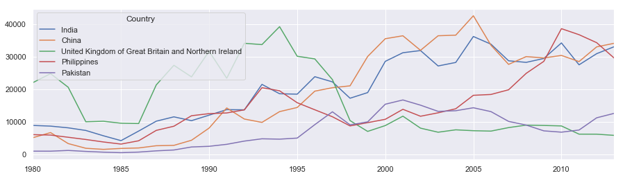

```python
can3=can2[years].transpose()
can3.plot(kind='line',figsize=(15,4))
```

# 7 plot area plot for Immigration Trend of Top 5 Countries

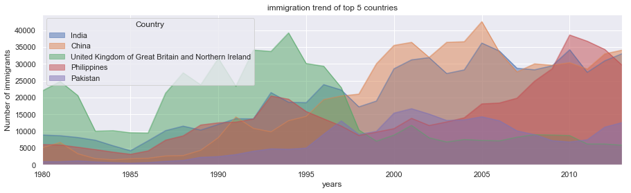

```python
can3.plot(kind='area',figsize=(15,4),stacked=False)
plt.xlabel('years')
plt.ylabel('Number of immigrants')
plt.title('immigration trend of top 5 countries')
```

# 8.9. Use the scripting layer to create a stacked area plot of the 5 countries that contributed the least to immigration to Canada from 1980 to 2013. Use a transparency value of 0.45.

```python
#can.drop(columns=['AREA'])
#can.sort_values(by='Total',ascending=True,axis=0)
can4=can.tail()
can4
```

| Country | Type | Coverage | AREA | Continent | REG | Region | DEV | DevName | 1980 | 1981 | ... | 2005 | 2006 | 2007 | 2008 | 2009 | 2010 | 2011 | 2012 | 2013 | Total |
| --- | --- | --- | --- | --- | --- | --- | --- | --- | --- | --- | --- | --- | --- | --- | --- | --- | --- | --- | --- | --- | --- |
| New Caledonia | Immigrants | Foreigners | 909 | Oceania | 928 | Melanesia | 902 | Developing regions | 0 | 0 | ... | 0 | 0 | 0 | 1 | 0 | 0 | 0 | 0 | 2 | 2744 |
| San Marino | Immigrants | Foreigners | 908 | Europe | 925 | Southern Europe | 901 | Developed regions | 1 | 0 | ... | 0 | 0 | 0 | 0 | 0 | 1 | 0 | 0 | 0 | 2739 |
| Canada | Immigrants | Citizens | 905 | Northern America | 905 | Northern America | 901 | Developed regions | 0 | 0 | ... | 0 | 0 | 0 | 0 | 0 | 0 | 1 | 1 | 2 | 2731 |
| Sao Tome and Principe | Immigrants | Foreigners | 903 | Africa | 911 | Middle Africa | 902 | Developing regions | 0 | 0 | ... | 1 | 1 | 0 | 0 | 1 | 2 | 0 | 0 | 1 | 2726 |
| Western Sahara | Immigrants | Foreigners | 903 | Africa | 912 | Northern Africa | 902 | Developing regions | 0 | 0 | ... | 0 | 1 | 0 | 0 | 0 | 0 | 0 | 0 | 0 | 2719 |

5 rows × 43 columns

```python
# this is artist
```

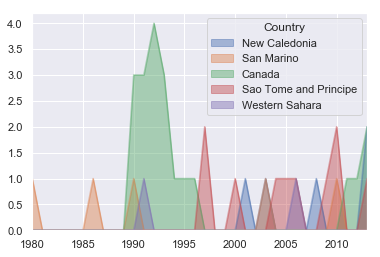

```python
can5=can4[years].transpose()
can5.plot(kind='area',alpha=0.45,stacked=False)
```

```python
# this is scripting
```

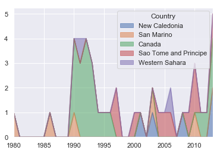

```python
can5.plot(kind='area',stacked=True,alpha=0.55)
```

# 10.What is the frequency distribution of the number (population) of new immigrants from the various countries to Canada in 2013?

```python
can[2013].head()
```

```
Country
India                                                   33087
China                                                   34129
United Kingdom of Great Britain and Northern Ireland     5827
Philippines                                             29544
Pakistan                                                12603
Name: 2013, dtype: int64
```

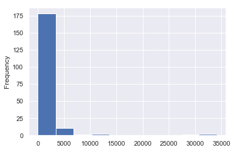

```python
can[2013].plot.hist()
```

```python
import numpy as np
count, bin_edges=np.histogram(can[2013])
print(count)
print(bin_edges)
```

```
[178  11   1   2   0   0   0   0   1   2]
[    0.   3412.9  6825.8 10238.7 13651.6 17064.5 20477.4 23890.3 27303.2
 30716.1 34129. ]
```

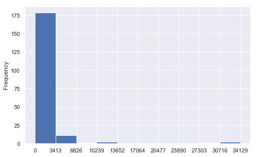

```python
can[2013].plot(kind='hist',figsize=(8,5),xticks=bin_edges)
plt.show()
```

# 11.What is the immigration distribution for Denmark, Norway, and Sweden for years 1980 - 2013?

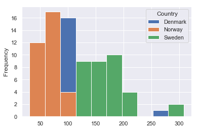

```python
denmark=can.loc[['Denmark','Norway','Sweden'],years]
denmark.transpose().plot.hist()
```

# 12.Use the scripting layer to display the immigration distribution for Greece, Albania, and Bulgaria for years 1980 - 2013? Use an overlapping plot with 15 bins and a transparency value of 0.35.

```python
greece=can.loc[['Greece','Albania','Bulgaria'],years]
greece
```

| Country | 1980 | 1981 | 1982 | 1983 | 1984 | 1985 | 1986 | 1987 | 1988 | 1989 | ... | 2004 | 2005 | 2006 | 2007 | 2008 | 2009 | 2010 | 2011 | 2012 | 2013 |
| --- | --- | --- | --- | --- | --- | --- | --- | --- | --- | --- | --- | --- | --- | --- | --- | --- | --- | --- | --- | --- | --- |
| Greece | 1065 | 953 | 897 | 633 | 580 | 584 | 547 | 765 | 564 | 773 | ... | 120 | 100 | 74 | 110 | 107 | 119 | 101 | 102 | 146 | 298 |
| Albania | 1 | 0 | 0 | 0 | 0 | 0 | 1 | 2 | 2 | 3 | ... | 1450 | 1223 | 856 | 702 | 560 | 716 | 561 | 539 | 620 | 603 |
| Bulgaria | 24 | 20 | 12 | 33 | 11 | 24 | 33 | 52 | 43 | 85 | ... | 2022 | 1738 | 1419 | 1172 | 994 | 784 | 556 | 365 | 451 | 512 |

3 rows × 34 columns

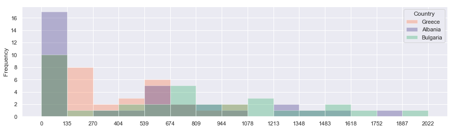

```python
count, bin_edges=np.histogram(greece,15)
greece.transpose().plot(kind='hist',bins=15,xticks=bin_edges,figsize=(15,4),alpha=0.35,color=['coral','darkslateblue','mediumseagreen'])
```

```python
import matplotlib
for name,hex in matplotlib.colors.cnames.items():
    print(name,hex)
```

[output not shown]

[output cut: 93 more lines]

[output not shown]

# 13.Compare the number of Icelandic immigrants (country = 'Iceland') to Canada from year 1980 to 2013.

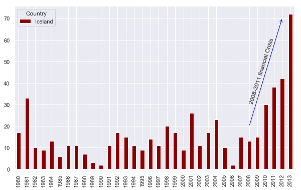

```python
iceland=can.loc[['Iceland'],years]
iceland.transpose().plot(kind='bar',figsize=(10,6),color=['darkred'])
plt.annotate('',xy=(32,70),xytext=(28,20),xycoords='data',# this is used to add an arrow in the plot
             arrowprops=dict(arrowstyle='->',connectionstyle='arc3',color='blue'))
plt.annotate('2008-2011 financial Crisis',
            xy=(28,30),
            rotation=72.5,
            va='bottom',
            ha='left',)
```

## 14.Using the scripting layer and the df dataset, create a horizontal bar plot showing the total number of immigrants to Canada from the top 15 countries, for the period 1980 - 2013. Label each country with the total immigrant count.

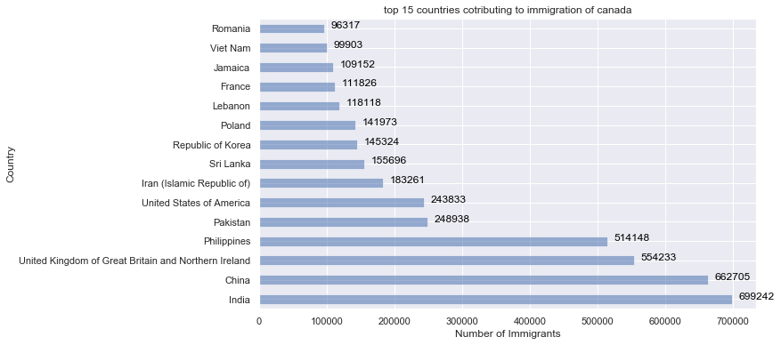

```python
cann2=can['Total'].nlargest(15)
cann2.plot(kind='barh',stacked=True,figsize=(10,6),alpha=0.55)
plt.xlabel('Number of Immigrants')
plt.title('top 15 countries cotributing to immigration of canada')
count=0
for val in cann2:
    plt.annotate(val,xy=(val+10000,count),color='black')
    count=count+1
plt.show()
#another way
# can.sort_values(by='Total',ascending=true,inplace=True)
#can15=
```

## 15. Box plot of Japanese Immigrants from 1980 - 2013

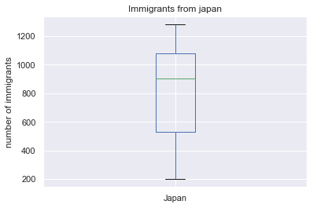

```python
can.loc['Japan',years].plot(kind='box')
plt.title('Immigrants from japan')
plt.ylabel('number of immigrants')
```

## 16. Box Plots of Immigrants from China and India (1980 - 2013)

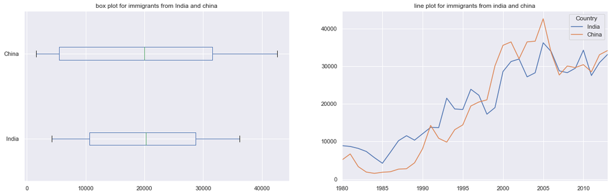

```python
fig=plt.figure()
ax0=fig.add_subplot(1,2,1)
ax1=fig.add_subplot(1,2,2)
china1=can.loc[['India','China'],years]
china1.transpose().plot(kind='box',vert=False,ax=ax0,figsize=(20,6),title='box plot for immigrants from India and china')
china1.transpose().plot(kind='line',ax=ax1,figsize=(20,6),title='line plot for immigrants from india and china')
```

## 17. plot scatter for Total Immigration to Canada from 1980 - 2013

```python
df_tot=pd.DataFrame(can[years].sum(axis=0))
df_tot.reset_index(inplace=True)
df_tot.columns=['years','total']
df_tot.head()
df_tot.years=list(map(int,df_tot.years))
```

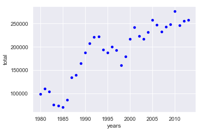

```python
#df_tot.years=list(map(int,df_tot.years))# converting the year column to integer
df_tot.head()
df_tot.plot(kind='scatter',x='years',y='total',color='blue')
```

## 18. plot line graph Total Immigration to Canada from 1980 - 2013

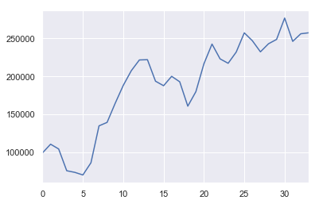

```python
df_tot['total'].plot(kind='line')
```

```python
can.set_index('Continent',inplace=True)
```

```python
df_continents=can.groupby('Continent',axis=0).sum()# first group the continents
df_continents.head()
```

| Continent | AREA | REG | DEV | 1980 | 1981 | 1982 | 1983 | 1984 | 1985 | 1986 | ... | 2005 | 2006 | 2007 | 2008 | 2009 | 2010 | 2011 | 2012 | 2013 | Total |
| --- | --- | --- | --- | --- | --- | --- | --- | --- | --- | --- | --- | --- | --- | --- | --- | --- | --- | --- | --- | --- | --- |
| Africa | 48762 | 49242 | 48708 | 3951 | 4363 | 3819 | 2671 | 2639 | 2650 | 3782 | ... | 27523 | 29188 | 28284 | 29890 | 34534 | 40892 | 35441 | 38083 | 38543 | 765660 |
| Asia | 45815 | 109147 | 44197 | 31025 | 34314 | 30214 | 24696 | 27274 | 23850 | 28739 | ... | 159253 | 149054 | 133459 | 139894 | 141434 | 163845 | 146894 | 152218 | 155075 | 3516953 |
| Europe | 39044 | 39754 | 38743 | 39760 | 44802 | 42720 | 24638 | 22287 | 20844 | 24370 | ... | 35955 | 33053 | 33495 | 34692 | 35078 | 33425 | 26778 | 29177 | 28691 | 1528488 |
| Latin America and the Caribbean | 29832 | 30395 | 29766 | 13081 | 15215 | 16769 | 15427 | 13678 | 15171 | 21179 | ... | 24747 | 24676 | 26011 | 26547 | 26867 | 28818 | 27856 | 27173 | 24950 | 855141 |
| Northern America | 1810 | 1810 | 1802 | 9378 | 10030 | 9074 | 7100 | 6661 | 6543 | 7074 | ... | 8394 | 9613 | 9463 | 10190 | 8995 | 8142 | 7677 | 7892 | 8503 | 246564 |

5 rows × 38 columns

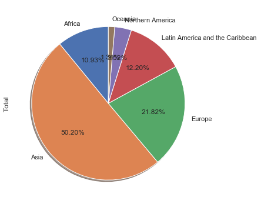

```python
# now calling the column
df_continents['Total'].plot(kind='pie',
                           figsize=(7,6),
                           autopct='%1.2f%%',# show the decimal point
                            startangle=90,
                           shadow=True)
```

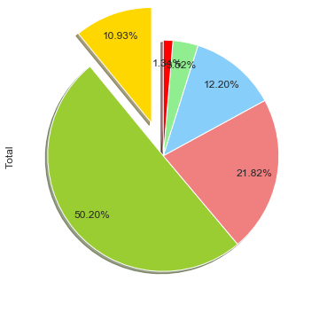

```python
# for slicing the pie plot
colors_list=['gold','yellowgreen','lightcoral','lightskyblue','lightgreen','red']
explode_list=[0.3,0,0,0,0,0]# ratio for each continent
df_continents['Total'].plot(kind='pie',
                           figsize=(6,6),
                           autopct='%1.2f%%',# show the decimal point
                            startangle=90,
                           shadow=True,
                           labels=None,# removed the labels
                           colors=colors_list,
                           explode=explode_list,
                           pctdistance=0.8)# changes the place of the  label
```